# Análisis Espectral No Paramétrico

## Objetivos

## Objetivo General

Profundizar en la teoría del análisis espectral no paramétrico así como sus aplicaciones en series de tiempo.

## Objetivos específicos

- Repasar los conceptos esenciales de la teoría del análisis espectral como análisis de Fourier, el periodograma, la densidad espectral y otros.
- Utilizar el programa estadístico R para filtrar la serie de las temperaturas máximas de Liberia, utilizado la teoría de análisis espectral.

## Marco Teórico

Cualquier proceso estacionario se puede representar mediante una combinación lineal de senos y cosenos se puede expresar aproximadamente de la siguiente forma:

\[X_t = \sum_{j = 1}^{q}[U_{j1} \cos(2\pi \omega_{j} t) + U_{j2} \sin(2\pi\omega_{j} t)]\]

Donde \(U_{k1}\), \(U_{k2}\) para \(k = 1,2,...,q\) son variable aleatorias con media cero y varianza \(\sigma_{k}^{2}\) y \(\omega_{j} = \frac{j}{n}\) son los ciclos.

## Datos

Serie: Temperaturas máximas diarias reportadas en Liberia entre el 2011 y 2014. *National Oceanic and Atmospheric Administration*

[interactive chart not shown]

## Estimación espectral no paramétrica

## Densidad espectral

\[f(\omega)= \sum_{-\infty}^\infty |\gamma(h)| e^{-2\pi i \omega h}\]

## El periodograma

Definimos la transformada discreta de Fourier (TDF) de \((x_{1}, ..., x_{t})\) como: \[d(\omega_j)=n^{-1/2} \sum_{t=1}^n x_t e^{2 \pi i \omega_j t}\] para \(j = 0,1,..., n - 1\)

Y, para el conjunto de datos \(x_{1}, ..., x_{n}\), se define el periodograma como: \[I(\omega_j)= |d(\omega_j)|^2\] para \(j = 0,1,..., n - 1\)

## El Periodograma

\[I(\omega_j)=\sum_{|h|<n} \hat{\gamma}(h) e^{-2 \pi i \omega_j h}\]

Donde \(I(\omega_j)\) es la versión muestral del poder de espectro \(\gamma _{0}f(\omega_j)\).

- Estimador espectral
- Descubrir los componentes periódicos de la serie

## El Periodograma

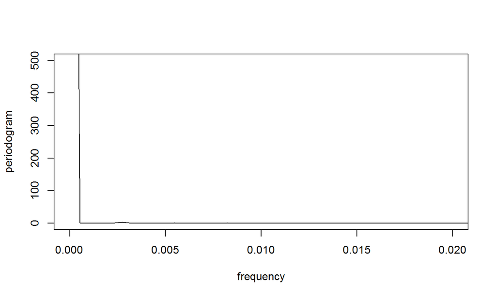

## El Periodograma

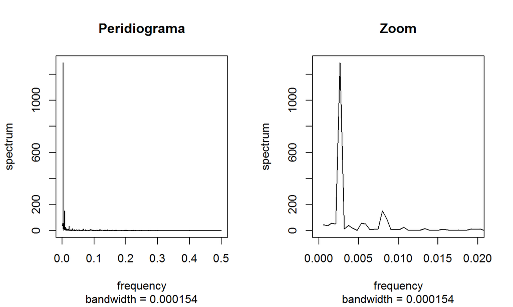

## El Periodograma

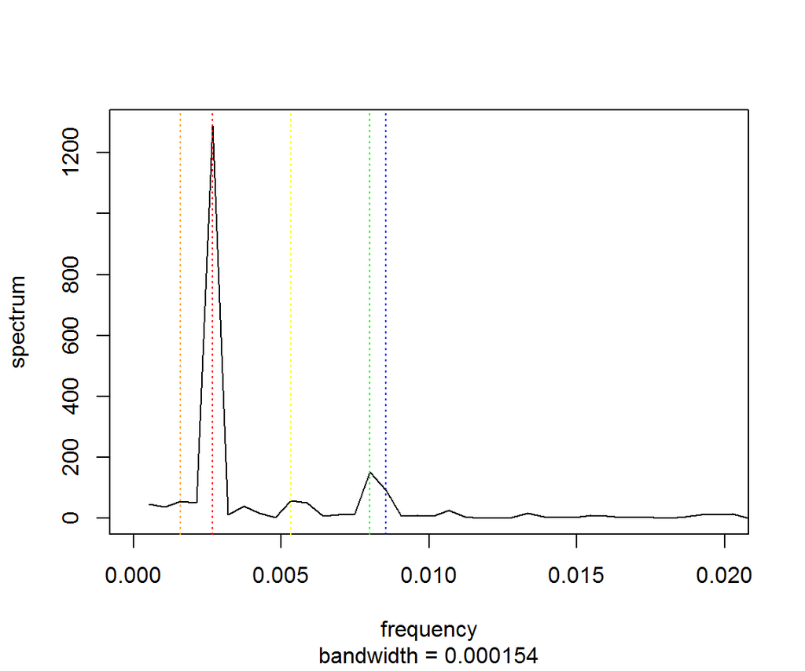

## El Periodograma

| Frecuencia | Periodo | Poder |
| --- | --- | --- |
| 0.00267 | 375.0000 | 1289.17963 |
| 0.00800 | 125.0000 | 152.00039 |
| 0.00853 | 117.1875 | 91.47463 |
| 0.00533 | 187.5000 | 56.90486 |
| 0.00160 | 625.0000 | 56.22760 |

## Propiedades Asintóticas

Para muestras grandes el periodograma converge en distribución a la densidad espectral: \[E[I(\omega_{j:n})] \leftarrow f(\omega)\] Dado que \(x_t\) es un proceso lineal con parámetros \(\psi_j\) sumables, se tiene que \[\frac{2\;I(\omega_{j:n})}{f(\omega_j)} \overset{d}{\longrightarrow} \chi^{2}_{2}\]

## Suavizado del periodograma

La idea general de los suavizadores consiste en ponderar las frecuencias alrededor de una frecuencia meta. El grado del suavizamiento depende entonces de dos aspectos principales:

-La cantidad \(L = 2m+1\) de frecuencias circundantes utilizadas para generar el estimador suavizado.

-Los pesos asignados a las frecuencias circundantes.

## Suavizado del periodograma

Bajo este concepto se puede describir cualquier método de suavizamiento mediante

\[ \bar{f}(\omega) = \sum_{k = -m}^{m} W_m(k) I(\omega + k/n) \]

## Suavizamiento del periodograma

\[ B = \{\omega^{*}: \omega_j - m/n \leq \omega^{*} \leq \omega_j + m/n\} \]

## Suavizado del peridiograma

| Freq | Lower | Upper | Power |
| --- | --- | --- | --- |
| 0.00267 | 329.38322 | 80982.434 | 1289.17963 |
| 0.00800 | 38.83584 | 9548.213 | 152.00039 |
| 0.00853 | 23.37161 | 5746.164 | 91.47463 |
| 0.00533 | 14.53910 | 3574.594 | 56.90486 |
| 0.00160 | 14.36606 | 3532.050 | 56.22760 |

## Suavizado del peridiograma

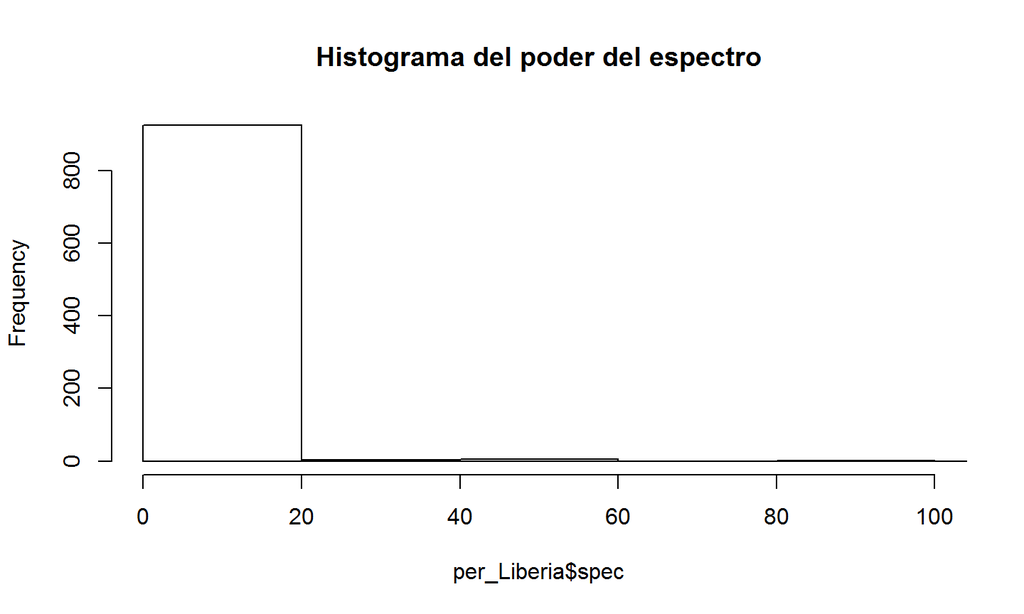

## Método de Daniell

El suavizador de Daniell está descrito por \[W_m(k) = \frac{1}{2m+1} = 1/L\]

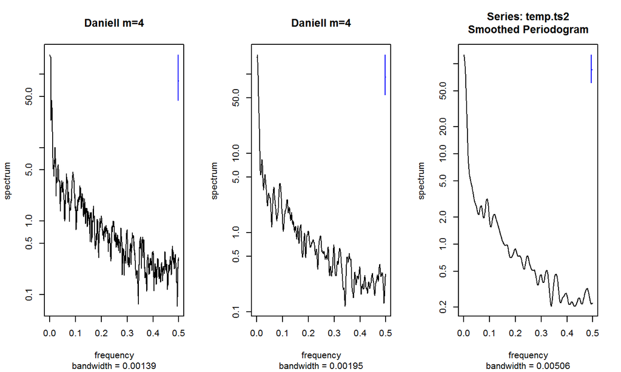

## Suavizado del peridiograma

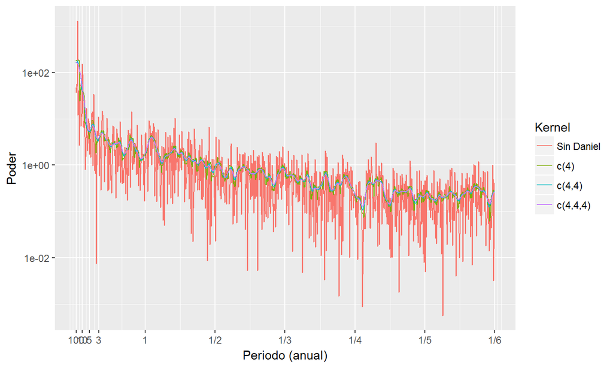

## Suavizado del peridiograma: Otros métodos

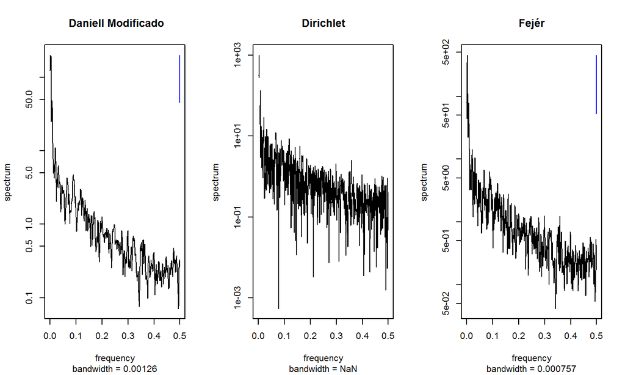

## Descomposición de la señal

[interactive chart not shown]

## Extracción de la señal

[interactive chart not shown]

## Conclusiones

-La serie tiene dos frecuencias importantes, una anual y otra cuatrimestral.